# R Notebook

```r
library(tidyverse) # Limpieza y transformación de datos
library(caret) # Generación de modelos y métricas
library(plotly) # Gráficos interactivos
library(rattle) # Datasets
library(lubridate) # Manejo de tipo de dato fecha en caso de haberlos
library(DescTools) # Imputar moda de ser necesario
library(mltools) # Usar encoders como onehotencoder
library(data.table)
library(pROC) # Curva ROC y valor AUC

# Carga de datos
data("audit")
```

```r
# Dimensión del dataset
dim(audit)
```

```
[1] 2000   13
```

```r
# Columnas del dataset
names(audit)
```

```
 [1] "ID"              "Age"             "Employment"      "Education"
 [5] "Marital"         "Occupation"      "Income"          "Gender"
 [9] "Deductions"      "Hours"           "IGNORE_Accounts" "RISK_Adjustment"
[13] "TARGET_Adjusted"
```

```r
# Estructura del dataset
str(audit)
```

```
'data.frame':   2000 obs. of  13 variables:
 $ ID             : int  1004641 1010229 1024587 1038288 1044221 1047095 1047698 1053888 1061323 1062363 ...
 $ Age            : int  38 35 32 45 60 74 43 35 25 22 ...
 $ Employment     : Factor w/ 8 levels "Consultant","Private",..: 2 2 2 2 2 2 2 2 2 2 ...
 $ Education      : Factor w/ 16 levels "Associate","Bachelor",..: 3 1 5 2 3 5 2 12 1 5 ...
 $ Marital        : Factor w/ 6 levels "Absent","Divorced",..: 5 1 2 3 3 3 3 3 2 1 ...
 $ Occupation     : Factor w/ 14 levels "Cleaner","Clerical",..: 12 14 2 10 3 12 3 6 2 11 ...
 $ Income         : num  81838 72099 154677 27744 7568 ...
 $ Gender         : Factor w/ 2 levels "Female","Male": 1 2 2 2 2 2 2 2 1 1 ...
 $ Deductions     : num  0 0 0 0 0 0 0 0 0 0 ...
 $ Hours          : int  72 30 40 55 40 30 50 40 40 37 ...
 $ IGNORE_Accounts: Factor w/ 33 levels "Canada","China",..: 31 18 31 31 31 31 31 31 31 31 ...
 $ RISK_Adjustment: int  0 0 0 7298 15024 0 22418 0 0 0 ...
 $ TARGET_Adjusted: int  0 0 0 1 1 0 1 0 0 0 ...
```

```r
# Primera vista del dataset
head(audit)
```

|  | ID | Age | Employment | Education | Marital | Occupation | Income | Gender | Deductions | Hours | IGNORE_Accounts | RISK_Adjustment | TARGET_Adjusted |
| --- | --- | --- | --- | --- | --- | --- | --- | --- | --- | --- | --- | --- | --- |
| 1 | 1004641 | 38 | Private | College | Unmarried | Service | 81838.00 | Female | 0 | 72 | UnitedStates | 0 | 0 |
| 2 | 1010229 | 35 | Private | Associate | Absent | Transport | 72099.00 | Male | 0 | 30 | Jamaica | 0 | 0 |
| 3 | 1024587 | 32 | Private | HSgrad | Divorced | Clerical | 154676.74 | Male | 0 | 40 | UnitedStates | 0 | 0 |
| 4 | 1038288 | 45 | Private | Bachelor | Married | Repair | 27743.82 | Male | 0 | 55 | UnitedStates | 7298 | 1 |
| 5 | 1044221 | 60 | Private | College | Married | Executive | 7568.23 | Male | 0 | 40 | UnitedStates | 15024 | 1 |
| 6 | 1047095 | 74 | Private | HSgrad | Married | Service | 33144.40 | Male | 0 | 30 | UnitedStates | 0 | 0 |

```r
# Drop de la columna ID
audit <- audit %>%
  select(-ID)
```

```r
# Valores nulos por columna
colSums(is.na(audit))
```

```
            Age      Employment       Education         Marital      Occupation
              0             100               0               0             101
         Income          Gender      Deductions           Hours IGNORE_Accounts
              0               0               0               0              43
RISK_Adjustment TARGET_Adjusted
              0               0
```

*Variables categoricas*

```r
# Definir que columnas son categóricas/factores
categorica <- c()
for (i in 1:ncol(audit)) {
  if (is.character(audit[[i]]) | is.factor(audit[[i]])){
    categorica <- c(categorica, names(audit)[i])
  }
}
cat("Cantidad de columnas categóricas:", length(categorica), "\n")
```

```
Cantidad de columnas categóricas: 6
```

```r
cat("Columnas categóricas:", categorica)
```

```
Columnas categóricas: Employment Education Marital Occupation Gender IGNORE_Accounts
```

```r
# Valores nulos en columnas categóricas
colSums(is.na(audit[, categorica]))
```

```
     Employment       Education         Marital      Occupation          Gender
            100               0               0             101               0
IGNORE_Accounts
             43
```

```r
# Valores únicos de columnas categóricas
sapply(audit[, categorica], unique)
```

```
$Employment
[1] Private    Consultant SelfEmp    PSLocal    PSState    PSFederal  Unemployed
[8] <NA>       Volunteer
8 Levels: Consultant Private PSFederal PSLocal PSState SelfEmp ... Volunteer

$Education
 [1] College      Associate    HSgrad       Bachelor     Yr12
 [6] Vocational   Master       Yr11         Yr10         Doctorate
[11] Yr9          Yr5t6        Professional Yr7t8        Preschool
[16] Yr1t4
16 Levels: Associate Bachelor College Doctorate HSgrad Master ... Yr9

$Marital
[1] Unmarried             Absent                Divorced
[4] Married               Widowed               Married-spouse-absent
Levels: Absent Divorced Married Married-spouse-absent Unmarried Widowed

$Occupation
 [1] Service      Transport    Clerical     Repair       Executive
 [6] Machinist    Sales        Professional Support      Cleaner
[11] Farming      <NA>         Protective   Home         Military
14 Levels: Cleaner Clerical Executive Farming Home Machinist ... Transport

$Gender
[1] Female Male
Levels: Female Male

$IGNORE_Accounts
 [1] UnitedStates Jamaica      Philippines  Mexico       Cuba
 [6] Malaysia     Germany      Vietnam      India        Indonesia
[11] Ireland      <NA>         Iran         England      Portugal
[16] Guatemala    China        Poland       Nicaragua    Singapore
[21] Hungary      Italy        Yugoslavia   Thailand     Taiwan
[26] NewZealand   Fiji         Columbia     Hong         Greece
[31] Scotland     Ecuador      Japan        Canada
33 Levels: Canada China Columbia Cuba Ecuador England Fiji Germany ... Yugoslavia
```

```r
# Cardinalidad de las columnas categoricas
sapply(audit[, categorica], function(x) length(unique(x)))
```

```
     Employment       Education         Marital      Occupation          Gender
              9              16               6              15               2
IGNORE_Accounts
             34
```

No existe alta cardinalidad por lo que dejamos los valores existentes.

```r
# Apariciones de los valores categóricos
sapply(audit[, categorica], table)
```

```
$Employment

Consultant    Private  PSFederal    PSLocal    PSState    SelfEmp Unemployed
       148       1411         69        119         72         79          1
 Volunteer
         1

$Education

   Associate     Bachelor      College    Doctorate       HSgrad       Master
          69          345          442           27          660          102
   Preschool Professional   Vocational         Yr10         Yr11         Yr12
           6           24           86           58           74           17
       Yr1t4        Yr5t6        Yr7t8          Yr9
           6           23           34           27

$Marital

               Absent              Divorced               Married
                  669                   266                   917
Married-spouse-absent             Unmarried               Widowed
                   22                    67                    59

$Occupation

     Cleaner     Clerical    Executive      Farming         Home    Machinist
          91          232          289           58            5          139
    Military Professional   Protective       Repair        Sales      Service
           1          247           40          225          206          210
     Support    Transport
          49          107

$Gender

Female   Male
   632   1368

$IGNORE_Accounts

      Canada        China     Columbia         Cuba      Ecuador      England
           2            7            2            2            2            5
        Fiji      Germany       Greece    Guatemala         Hong      Hungary
           1            6            1            6            1            1
       India    Indonesia         Iran      Ireland        Italy      Jamaica
           7            3            3            6            2            5
       Japan     Malaysia       Mexico   NewZealand    Nicaragua  Philippines
           2            5           43            2            4           13
      Poland     Portugal     Scotland    Singapore       Taiwan     Thailand
           2            2            1            3            4            1
UnitedStates      Vietnam   Yugoslavia
        1804            8            1
```

Hay valores que tienen una o dos instancias, lo que será un problema cuando dividamos los datos en entrenamiento y prueba, por lo que los eliminaremos.

```r
frecuencias <- sapply(audit[, categorica], table)
for (col in categorica){
  valores <- names(frecuencias[[col]][frecuencias[[col]] > 2])
  audit <- audit[audit[[col]] %in% valores, ]
}

sapply(audit[, categorica], table)
```

```
$Employment

Consultant    Private  PSFederal    PSLocal    PSState    SelfEmp Unemployed
       147       1363         67        114         70         74          0
 Volunteer
         0

$Education

   Associate     Bachelor      College    Doctorate       HSgrad       Master
          62          319          408           22          617           93
   Preschool Professional   Vocational         Yr10         Yr11         Yr12
           6           22           79           52           65           15
       Yr1t4        Yr5t6        Yr7t8          Yr9
           5           17           30           23

$Marital

               Absent              Divorced               Married
                  607                   248                   851
Married-spouse-absent             Unmarried               Widowed
                   21                    62                    46

$Occupation

     Cleaner     Clerical    Executive      Farming         Home    Machinist
          90          219          283           55            5          131
    Military Professional   Protective       Repair        Sales      Service
           0          235           39          222          204          197
     Support    Transport
          49          106

$Gender

Female   Male
   566   1269

$IGNORE_Accounts

      Canada        China     Columbia         Cuba      Ecuador      England
           0            6            0            0            0            5
        Fiji      Germany       Greece    Guatemala         Hong      Hungary
           0            6            0            6            0            0
       India    Indonesia         Iran      Ireland        Italy      Jamaica
           7            3            3            6            0            5
       Japan     Malaysia       Mexico   NewZealand    Nicaragua  Philippines
           0            4           43            0            4           13
      Poland     Portugal     Scotland    Singapore       Taiwan     Thailand
           0            0            0            3            4            0
UnitedStates      Vietnam   Yugoslavia
        1709            8            0
```

```r
# Imputar valores nulos con la moda
audit <- audit %>%
  mutate(across(where(is.factor), ~ifelse(is.na(.), Mode(., na.rm=T), .)))
```

```r
colSums(is.na(audit))
```

```
            Age      Employment       Education         Marital      Occupation
              0               0               0               0               0
         Income          Gender      Deductions           Hours IGNORE_Accounts
              0               0               0               0               0
RISK_Adjustment TARGET_Adjusted
              0               0
```

*Variables numéricas*

```r
# Variables numéricas
numerica <- c()
for (i in 1:ncol(audit)) {
  if (is.numeric(audit[[i]])){
    numerica <- c(numerica, names(audit)[[i]])
  }
}
cat("Cantidad de columnas numéricas:", length(numerica), "\n")
```

```
Cantidad de columnas numéricas: 12
```

```r
cat("Columnas numéricas:", numerica)
```

```
Columnas numéricas: Age Employment Education Marital Occupation Income Gender Deductions Hours IGNORE_Accounts RISK_Adjustment TARGET_Adjusted
```

```r
# Valores nulos en variables numéricas
colSums(is.na(audit[, numerica]))
```

```
            Age      Employment       Education         Marital      Occupation
              0               0               0               0               0
         Income          Gender      Deductions           Hours IGNORE_Accounts
              0               0               0               0               0
RISK_Adjustment TARGET_Adjusted
              0               0
```

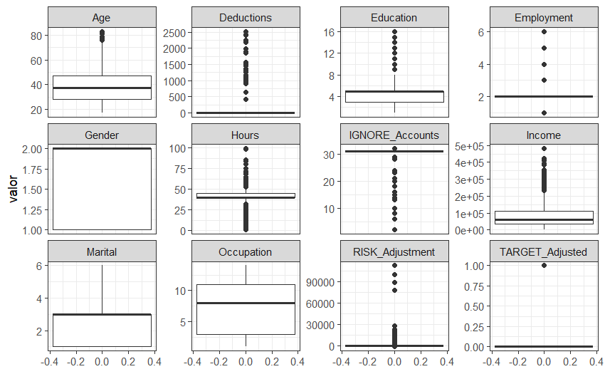

```r
# Boxplot para analizar presencia de outliers
audit %>%
  select(numerica) %>%
  gather(key="variable", value="valor") %>%
  ggplot() +
  aes(y=valor) +
  geom_boxplot() +
  facet_wrap(~ variable, scales="free_y") +
  theme_bw()
```

Observamos presencia de outliers por lo que pasamos a analizar la distribución de las columnas.

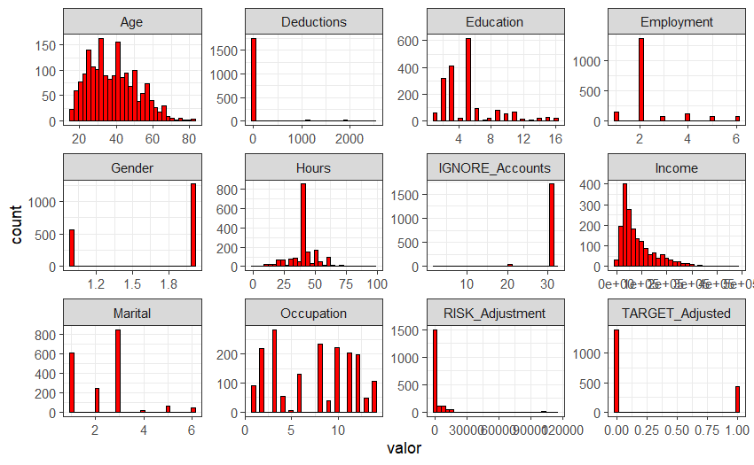

```r
# Distribución de variables numéricas
audit %>%
  select(numerica) %>%
  gather(key="variable", value="valor") %>%
  ggplot() +
  aes(x=valor) +
  geom_histogram(color="black", fill="red", bins=30) +
  facet_wrap(~ variable, scales="free") +
  theme_bw()
```

Vemos que las distribuciones están sesgadas positivamente (cola larga a la derecha). Buscaremos outliers con el IQR para principalmente “AGE”, “INCOME” y “HOURS”.

```r
outliers <- function(x){
  quantiles <- quantile(x, c(0.25, 0.75))
  iqr <- IQR(x)
  lower_bound <- quantiles[1] - iqr * 1.5
  upper_bound <- quantiles[2] + iqr * 1.5
  cat("Límite inferior:", lower_bound, "\n")
  cat("Límite superior:", upper_bound, "\n")
  cat("Mínimo:", min(x), "\n")
  cat("Máximo:", max(x), "\n")
}

sapply(audit[, numerica], outliers)
```

```
Límite inferior: -0.5
Límite superior: 75.5
Mínimo: 17
Máximo: 83
Límite inferior: 2
Límite superior: 2
Mínimo: 1
Máximo: 6
Límite inferior: 0
Límite superior: 8
Mínimo: 1
Máximo: 16
Límite inferior: -2
Límite superior: 6
Mínimo: 1
Máximo: 6
Límite inferior: -9
Límite superior: 23
Mínimo: 1
Máximo: 14
Límite inferior: -84444.17
Límite superior: 230676.2
Mínimo: 609.72
Máximo: 481259.5
Límite inferior: -0.5
Límite superior: 3.5
Mínimo: 1
Máximo: 2
Límite inferior: 0
Límite superior: 0
Mínimo: 0
Máximo: 2513.333
Límite inferior: 32.5
Límite superior: 52.5
Mínimo: 1
Máximo: 99
Límite inferior: 31
Límite superior: 31
Mínimo: 2
Máximo: 32
```

[output cut: 28 more lines]

```

$Deductions
NULL

$Hours
NULL

$IGNORE_Accounts
NULL

$RISK_Adjustment
NULL

$TARGET_Adjusted
NULL
```

En la columna “AGE” el límite inferior es -0.5 y el superior es 75.5. El valor mínimo es 17 y el máximo es 83, por lo que los outliers son los valores > 75.5. En la columna “INCOME” el límite inferior es -84444.17 y el superior es 230676.2. El valor mínimo es 609.72 y el máximo es 481259.5, por lo que los outliers son los valores > 230676.2. En la columna “HOURS” el límite inferior es 32.5 y el superior es 52.5. El valor mínimo es 1 y el máximo es 99, por lo que los outliers son los valores < 32.5 y > 52.5.

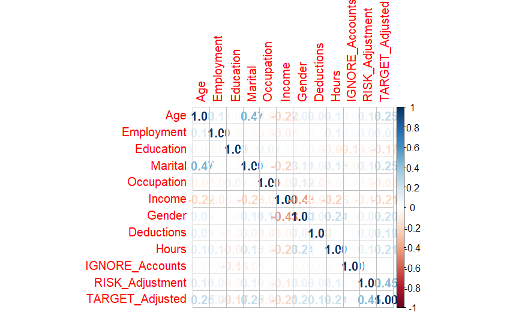

```r
# Correlación entre variables
correlacion <- cor(audit)

corrplot::corrplot(correlacion, method="number")
```

```r
# Distribución de la variable target
table(audit$TARGET_Adjusted)
```

```
   0    1
1400  435
```

```r
prop.table(table(audit$TARGET_Adjusted))
```

```
        0         1
0.7629428 0.2370572
```

```r
# Features y target
X <- audit %>%
  select(-TARGET_Adjusted)
X$Gender <- as.factor(X$Gender)
X$Employment <- as.factor(X$Employment)
X$Education <- as.factor(X$Education)
X$Marital <- as.factor(X$Marital)
X$Occupation <- as.factor(X$Occupation)

y <- as.factor(audit$TARGET_Adjusted)
```

```r
# Train y test sets
indice <- createDataPartition(y, p=0.8, list=F)

X_train <- X[indice, ]
X_test <- X[-indice, ]
y_train <- y[indice]
y_test <- y[-indice]
```

*Feature Engineering*

```r
# Dimensiones del set de  entrenamiento y prueba
dim(X_train)
```

```
[1] 1468   11
```

```r
dim(X_test)
```

```
[1] 367  11
```

```r
# Presencia de valores nulos
sum(is.na(X_train))
```

```
[1] 0
```

```r
sum(is.na(X_test))
```

```
[1] 0
```

```r
# Transformar outliers
valor_max <- function(df, variable, top){
  df[[variable]] <- pmin(df[[variable]], top, na.rm=T)
  return(df)
}

valor_min <- function(df, variable, bottom) {
  df[[variable]] <- pmax(df[[variable]], bottom, na.rm = TRUE)
  return(df)
}

for (df1 in c("X_train", "X_test")){
  assign(df1, valor_max(get(df1), "Age", 75.5))
  assign(df1, valor_max(get(df1), "Income", 230676.2))
  assign(df1, valor_max(get(df1), "Hours", 52.5))
  assign(df1, valor_min(get(df1), "Hours", 32.5))
}

head(X_train)
```

|  | Age | Employment | Education | Marital | Occupation | Income | Gender | Deductions | Hours | IGNORE_Accounts | RISK_Adjustment |
| --- | --- | --- | --- | --- | --- | --- | --- | --- | --- | --- | --- |
| 1 | 38 | 2 | 3 | 5 | 12 | 81838.00 | 1 | 0 | 52.5 | 31 | 0 |
| 2 | 35 | 2 | 1 | 1 | 14 | 72099.00 | 2 | 0 | 32.5 | 18 | 0 |
| 3 | 32 | 2 | 5 | 2 | 2 | 154676.74 | 2 | 0 | 40.0 | 31 | 0 |
| 4 | 45 | 2 | 2 | 3 | 10 | 27743.82 | 2 | 0 | 52.5 | 31 | 7298 |
| 5 | 60 | 2 | 3 | 3 | 3 | 7568.23 | 2 | 0 | 40.0 | 31 | 15024 |
| 6 | 74 | 2 | 5 | 3 | 12 | 33144.40 | 2 | 0 | 32.5 | 31 | 0 |

```r
head(X_test)
```

|  | Age | Employment | Education | Marital | Occupation | Income | Gender | Deductions | Hours | IGNORE_Accounts | RISK_Adjustment |
| --- | --- | --- | --- | --- | --- | --- | --- | --- | --- | --- | --- |
| 11 | 48 | 2 | 3 | 2 | 12 | 230676.20 | 1 | 0 | 35.0 | 31 | 0 |
| 15 | 50 | 2 | 6 | 3 | 3 | 34919.16 | 2 | 0 | 40.0 | 24 | 7298 |
| 19 | 65 | 6 | 3 | 3 | 11 | 32963.39 | 2 | 0 | 40.0 | 31 | 0 |
| 20 | 28 | 2 | 3 | 3 | 3 | 31534.97 | 2 | 0 | 52.5 | 31 | 0 |
| 21 | 40 | 4 | 9 | 2 | 3 | 182165.08 | 1 | 0 | 40.0 | 31 | 0 |
| 25 | 23 | 2 | 11 | 5 | 8 | 230676.20 | 2 | 0 | 35.0 | 31 | 0 |

*Modelado*

```r
set.seed(1223)
control <- trainControl(method="cv", number=10)
modelo_reg_log <- train(x=X_train,
                        y=y_train,
                        method="glm",
                        family=binomial(),
                        trControl=control)
pred_reg_log <- predict(modelo_reg_log, X_test)
conf_mat_rl <- confusionMatrix(pred_reg_log, y_test, positive="1")
conf_mat_rl
```

```
Confusion Matrix and Statistics

          Reference
Prediction   0   1
         0 279  16
         1   1  71

               Accuracy : 0.9537
                 95% CI : (0.9269, 0.9728)
    No Information Rate : 0.7629
    P-Value [Acc > NIR] : < 2.2e-16

                  Kappa : 0.8639

 Mcnemar's Test P-Value : 0.000685

            Sensitivity : 0.8161
            Specificity : 0.9964
         Pos Pred Value : 0.9861
         Neg Pred Value : 0.9458
             Prevalence : 0.2371
         Detection Rate : 0.1935
   Detection Prevalence : 0.1962
      Balanced Accuracy : 0.9063

       'Positive' Class : 1
```

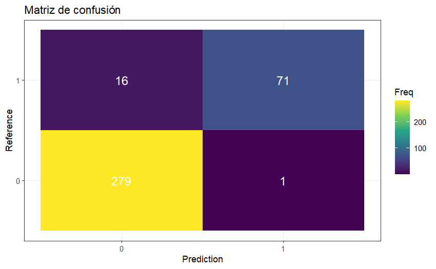

```r
# Gráfico de la matriz de confusión
mat_conf_rl <- as.data.frame(conf_mat_rl$table)

mat_conf_rl %>%
  ggplot() +
  aes(x=Prediction, y=Reference, fill=Freq) +
  geom_tile() +
  geom_text(aes(label=Freq), color="white", size=5) +
  scale_fill_viridis_c() +
  labs(title="Matriz de confusión") +
  theme_bw()
```

```r
# Evaluar la posibilidad de overfitting en el modelo
sum(predict(modelo_reg_log, X_train) == y_train) / length(y_train)
```

```
[1] 0.9618529
```

```r
sum(predict(modelo_reg_log, X_test) == y_test) / length(y_test)
```

```
[1] 0.9536785
```

```r
# F1 SCORE
conf_mat_rl$byClass["F1"]
```

```
       F1
0.8930818
```

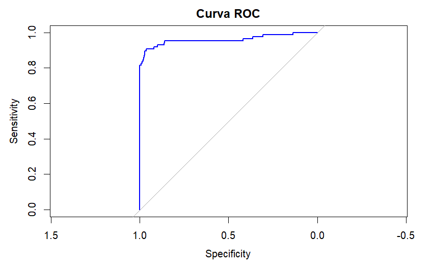

```r
# Curva ROC y AUC
probs <- predict(modelo_reg_log, X_test, type="prob")
roc_c <- roc(as.numeric(y_test), as.numeric(probs[, 2]))
plot(roc_c, col="blue", main="Curva ROC")
```

```r
auc(roc_c)
```

```
Area under the curve: 0.9608
```

Acurracy de 95.4%, buen rendimiento del modelo. Diferencia entre train set y test set insignificante, por lo que no hay signos de overfitting. AUC de 0.96, excelente capacidad predictiva, casi perfecta. F1 score de 0.89, buen equilibrio entre precisión (evita falsos positivos) y recall (detecta instancias positivas correctamente).